# IJ_Crime_Reporting_Data

Dilruba Tas

2026-10-22

```r
##2020
## DS0005

`38090.0005.Data` <- read.delim("ICPSR_38090/DS0005/38090-0005-Data.tsv")
```

```r
##2021
 `38429.0005.Data` <- read.delim("ICPSR_38429/DS0005/38429-0005-Data.tsv")
```

```r
## 2022
`38603.0005.Data` <- read.delim("ICPSR_38603/DS0005/38603-0005-Data.tsv")
```

```r
## 2023
`38962.0005.Data` <- read.delim("ICPSR_38962/DS0005/38962-0005-Data.tsv")
```

```r
vars <- c("IDHH", "IDPER", "V4399", "V4400", "V4421", "V4422", "V4423",
          "V4436", "V4437", "V4529", "WGTVICCY", "YEARQ", "SERIES_IWEIGHT",
          "V2117", "V2118",                    # variance strata and PSU
          "V4022",                             # location (1 = outside U.S.)
          "V4411", "V4412", "V4413", "V4414")  # police-related reasons (all that apply)


incidents_2020 <- `38090.0005.Data`  %>% select(all_of(vars))
incidents_2021 <-  `38429.0005.Data`  %>% select(all_of(vars))
incidents_2022 <- `38603.0005.Data`   %>% select(all_of(vars))
incidents_2023 <- `38962.0005.Data`   %>% select(all_of(vars))

# BJS excludes incidents that occurred outside the U.S. from published estimates
merged_all <- bind_rows(incidents_2020, incidents_2021, incidents_2022, incidents_2023) %>%
  filter(parse_number(as.character(V4022)) != 1)
```

```r
toc_codes <- c(1:29, 31:41, 54:59)
toc_labels <- c(
  # Violent (1-20)
  "Completed rape", "Attempted rape",
  "Sexual assault with serious assault", "Sexual assault with minor assault",
  "Robbery with injury, serious assault", "Robbery with injury, minor assault",
  "Robbery without injury",
  "Attempted robbery with injury, serious assault",
  "Attempted robbery with injury, minor assault",
  "Attempted robbery without injury",
  "Aggravated assault with injury",
  "Attempted aggravated assault with weapon",
  "Threatened assault with weapon",
  "Simple assault with injury",
  "Sexual assault without injury",
  "Unwanted sexual contact without force",
  "Assault without weapon, without injury",
  "Verbal threat of rape", "Verbal threat of sexual assault",
  "Verbal threat of assault",
  # Personal theft with contact (21-23)
  "Purse snatching", "Attempted purse snatching", "Pocket picking",
  # Old code list: personal larceny without contact (24-29)
  "Personal larceny without contact, < $10",
  "Personal larceny without contact, $10-49",
  "Personal larceny without contact, $50-249",
  "Personal larceny without contact, $250+",
  "Personal larceny without contact, value NA",
  "Attempted personal larceny without contact",
  # Burglary (31-33)
  "Burglary, forcible entry", "Burglary, entry without force",
  "Attempted forcible entry",
  # Old code list: household larceny (34-39)
  "Household larceny, < $10", "Household larceny, $10-49",
  "Household larceny, $50-249", "Household larceny, $250+",
  "Household larceny, value NA", "Attempted household larceny",
  # Motor vehicle theft (40-41)
  "Motor vehicle theft", "Attempted motor vehicle theft",
  # New code list: theft (54-59)
  "Theft, < $10", "Theft, $10-49", "Theft, $50-249", "Theft, $250+",
  "Theft, value NA", "Attempted theft"
)
```

```r
main_df <- merged_all %>%
  select(all_of(vars)) %>%
  rename(id_household = IDHH, id_person = IDPER, year_quarter = YEARQ, reported_police = V4399, police_found_out = V4400, reason_not_reported = V4421, reason_not_reported_most = V4422, reason_reported = V4423, reason_reported_res = V4436, reason_reported_most = V4437, type_of_crime = V4529, weight_victim = WGTVICCY, weight_series = SERIES_IWEIGHT,
         var_strata = V2117, var_psu = V2118,
         nr_police_not_important = V4411, nr_police_ineffective = V4412,
         nr_police_biased = V4413, nr_offender_police = V4414) %>%
  mutate(year = floor(as.numeric(as.character(year_quarter))),
         across(c(reported_police, police_found_out, reason_not_reported,
             reason_not_reported_most, reason_reported, reason_reported_res,
             reason_reported_most, type_of_crime),
             ~ parse_number(as.character(.x))),
         # 0 = No, 1 = Yes; 8 (residue) and 9 (out of universe) become NA
         across(starts_with("nr_"),
             ~ if_else(parse_number(as.character(.x)) %in% 0:1,
                       parse_number(as.character(.x)), NA_real_)),
         design_strata = interaction(year, var_strata, drop = TRUE),
             reported_police = factor(reported_police, levels = c(1,2,3,8)),
             police_found_out = factor(police_found_out, levels = c(1,2,3,4,5,6,7,98,99)),
             reason_not_reported_most = factor(reason_not_reported_most, levels = c(1:19, 30, 98, 99)),
             reason_reported_most = factor(reason_reported_most, levels = c(1:12, 21:22, 98:99)),
             reported_police = fct_recode(reported_police,
                                 "Yes"        = "1",
                                 "No"         = "2",
                                 "Don't know" = "3",
                                 "Residue"    = "8"),
             police_found_out = fct_recode(police_found_out,
                                "Respondent"             = "1",
                                "Other Household Member" = "2",
                                "Someone Official"       = "3",
                                "Someone else"           = "4",
                                "Police at scene"        = "5",
                                "Offender was a police officer"                = "6",
                                "Some other way"        = "7",
                                "Residue"               = "98",
                                "Oou"                   = "99"),
             crime_detail = factor(type_of_crime, levels = toc_codes, labels = toc_labels),

              crime_type = case_when(
                 type_of_crime %in% c(1:4, 15, 16, 18, 19) ~ "Rape/sexual assault",
                 type_of_crime %in% 5:10                   ~ "Robbery",
                 type_of_crime %in% 11:13                  ~ "Aggravated assault",
                 type_of_crime %in% c(14, 17, 20)          ~ "Simple assault",
                 type_of_crime %in% 21:23                  ~ "Personal theft (with contact)",
                 type_of_crime %in% 31:33                  ~ "Burglary",
                 type_of_crime %in% 40:41                  ~ "Motor vehicle theft",
                 type_of_crime %in% c(54:59, 24:29, 34:39) ~ "Other theft",
         TRUE ~ NA_character_
    ),
           crime_type = factor(crime_type, levels = c(
            "Rape/sexual assault", "Robbery", "Aggravated assault", "Simple assault",
            "Personal theft (with contact)", "Burglary", "Motor vehicle theft", "Other theft"
    )),

           crime_class = case_when(
                type_of_crime %in% 1:20                          ~ "Violent",
                type_of_crime %in% 21:23                         ~ "Personal theft",
                type_of_crime %in% c(31:33, 40:41, 54:59, 24:29, 34:39) ~ "Property",
      TRUE ~ NA_character_
    ),
    reason_not_reported_most = fct_recode(reason_not_reported_most,

      "Reported to another official"            = "1",
      "Private or personal matter"              = "2",
      "Minor or unsuccessful crime"             = "3",
      "Child offender, kid stuff"               = "4",
      "Not clear it was a crime"                = "5",
      "No insurance, loss below deductible"     = "6",
      "Found out too late"                      = "7",
      "Could not recover property"              = "8",
      "Could not identify offender"             = "9",
      "Police would not think it important"     = "10",
      "Police would be ineffective"             = "11",
      "Police would be biased"                  = "12",
      "Offender was a police officer"           = "13",
      "Did not want to get offender in trouble" = "14",
      "Advised not to report"                   = "15",
      "Fear of reprisal"                        = "16",
      "Too inconvenient"                        = "17",
      "Other reason"                            = "18",
      "Respondent not present, don't know"      = "19",
      "No one reason more important"            = "30",
      "Residue"                                 = "98",
      "Oou"                                     = "99"
    ),
    reason_reported_most = fct_recode(reason_reported_most,
      "Stop or prevent this incident"              = "1",
      "Needed help after incident"                 = "2",
      "Recover property"                           = "3",
      "Collect insurance"                          = "4",
      "Prevent further crimes against household"   = "5",
      "Stop offender from committing other crimes" = "6",
      "Punish offender"                            = "7",
      "Catch offender"                             = "8",
      "Improve police surveillance of area"        = "9",
      "Duty to tell police"                        = "10",
      "Other reason"                               = "11",
      "No other reason"                            = "12",
      "No one reason more important"               = "21",
      "Because it was a crime"                     = "22",
      "Residue"                                    = "98",
      "Oou"                                        = "99"
    ),
    reason_reported_group = fct_collapse(reason_reported_most,
      "Stop or prevent crime"       = c("Stop or prevent this incident",
                                        "Prevent further crimes against household",
                                        "Stop offender from committing other crimes",
                                        "Improve police surveillance of area"),
      "Get help or recover losses"  = c("Needed help after incident",
                                        "Recover property",
                                        "Collect insurance"),
      "Hold offender accountable"   = c("Punish offender",
                                        "Catch offender"),
      "Civic duty"                  = c("Duty to tell police",
                                        "Because it was a crime"),
      "Other"                       = c("Other reason",
                                        "No other reason",
                                        "No one reason more important")
    ),
     reason_not_reported_group = fct_collapse(reason_not_reported_most,
      "Handled another way"      = "Reported to another official",
      "Private/personal"         = "Private or personal matter",
      "Not important enough"     = c("Minor or unsuccessful crime",
                                     "Child offender, kid stuff",
                                     "Not clear it was a crime",
                                     "No insurance, loss below deductible"),
      "Practical barriers"       = c("Found out too late",
                                     "Could not recover property",
                                     "Could not identify offender",
                                     "Too inconvenient"),
      "Police-related"           = c("Police would not think it important",
                                     "Police would be ineffective",
                                     "Police would be biased",
                                     "Offender was a police officer"),
      "Protecting offender/self" = c("Did not want to get offender in trouble",
                                     "Advised not to report",
                                     "Fear of reprisal"),
      "Other"                    = c("Other reason",
                                     "Respondent not present, don't know",
                                     "No one reason more important")
    )
  )
```

```r
unreported_by_type <- main_df %>%
  filter(reported_police %in% c("Yes", "No"), !is.na(crime_type)) %>%
  group_by(crime_type) %>%
  summarise(
    n_incidents    = n(),
    pct_unreported = 100 * weighted.mean(reported_police == "No", w = weight_series),
    .groups = "drop"
  )
```

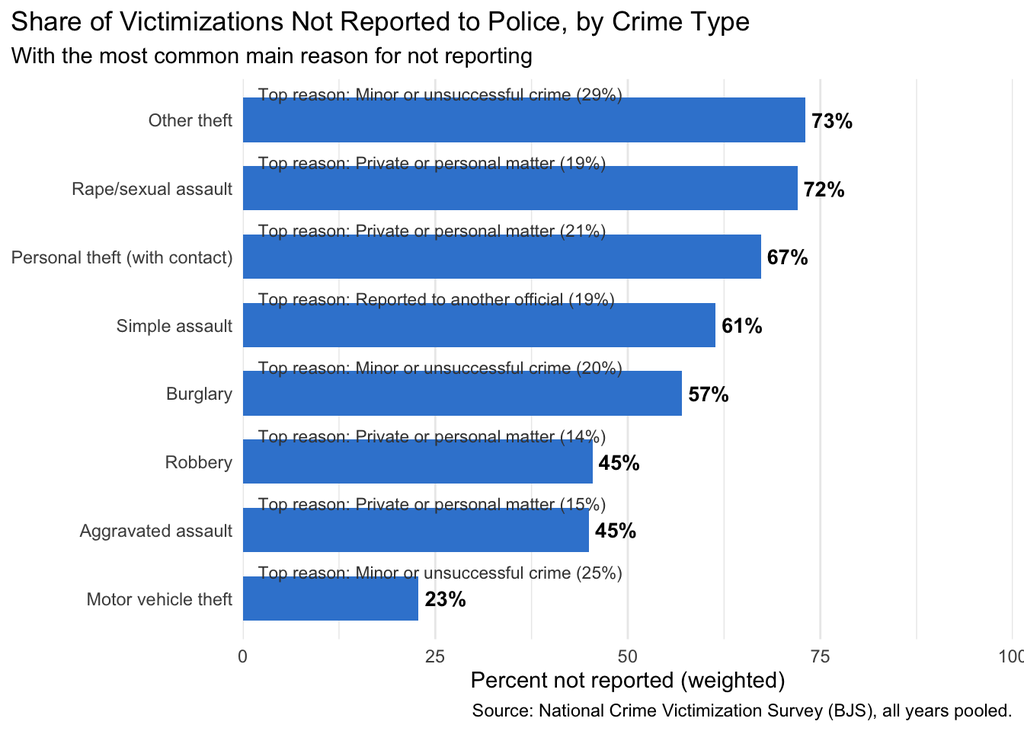

```r
top_reason_by_type <- main_df %>%
  filter(reported_police == "No",
         !is.na(crime_type), !is.na(reason_not_reported_most)) %>%
  count(crime_type, reason_not_reported_most, wt = weight_series) %>%
  group_by(crime_type) %>%
  mutate(pct_of_unreported = 100 * n / sum(n)) %>%
  slice_max(pct_of_unreported, n = 1, with_ties = FALSE) %>%
  ungroup() %>%
  select(crime_type, top_reason = reason_not_reported_most, pct_of_unreported)

chart1_df <- unreported_by_type %>%
  left_join(top_reason_by_type, by = "crime_type") %>%
  mutate(
    label = paste0("Top reason: ", top_reason, " (", round(pct_of_unreported), "%)"),
    crime_type = fct_reorder(crime_type, pct_unreported)
  )

p_unreported <- ggplot(chart1_df, aes(x = pct_unreported, y = crime_type)) +
  geom_col(fill = "#3a86d4", width = 0.65) +
  geom_text(aes(label = paste0(round(pct_unreported), "%")),
            hjust = -0.15, fontface = "bold", size = 3.6) +
  geom_text(aes(x = 2, label = label),
            hjust = 0, vjust = -1.6, size = 3, color = "grey25") +
  scale_x_continuous(limits = c(0, 100), expand = c(0, 0)) +
  labs(
    title = "Share of Victimizations Not Reported to Police, by Crime Type",
    subtitle = "With the most common main reason for not reporting",
    x = "Percent not reported (weighted)", y = NULL,
    caption = "Source: National Crime Victimization Survey (BJS), all years pooled."
  ) +
  theme_minimal(base_size = 11) +
  theme(panel.grid.major.y = element_blank(),
        plot.title.position = "plot")

p_unreported
```

```r
reasons_heat_df <- main_df %>%
  filter(reported_police == "No",
         !is.na(crime_type), !is.na(reason_not_reported_group)) %>%
  count(crime_type, reason_not_reported_group, wt = weight_series) %>%
  group_by(crime_type) %>%
  mutate(pct = 100 * n / sum(n)) %>%
  ungroup()
```

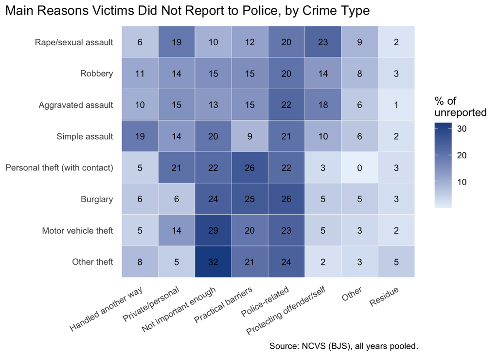

```r
p_reasons_heat <- ggplot(reasons_heat_df,
                         aes(x = reason_not_reported_group, y = fct_rev(crime_type), fill = pct)) +
  geom_tile(color = "white") +
  geom_text(aes(label = round(pct)), size = 3.2,
            color = ifelse(reasons_heat_df$pct > 35, "white", "black")) +
  scale_fill_gradient(low = "#eaf2fb", high = "#1d4f91", name = "% of\nunreported") +
  labs(
    title = "Main Reasons Victims Did Not Report to Police, by Crime Type",
    x = NULL, y = NULL,
    caption = "Source: NCVS (BJS), all years pooled."
  ) +
  theme_minimal(base_size = 11) +
  theme(axis.text.x = element_text(angle = 30, hjust = 1),
        panel.grid = element_blank(),
        plot.title.position = "plot")

p_reasons_heat
```

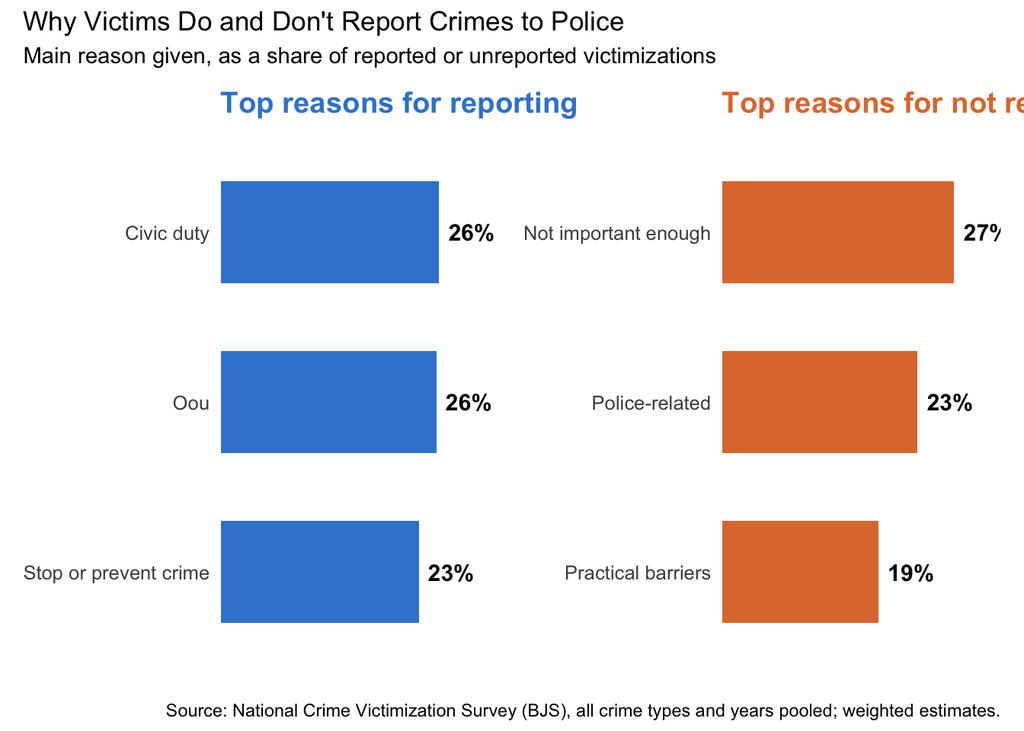

```r
valid <- main_df %>% filter(reported_police %in% c("Yes", "No"))

# Top 3 reasons FOR reporting (share of reported victimizations)
top3_rep <- valid %>%
  filter(reported_police == "Yes", !is.na(reason_reported_group)) %>%
  count(reason = reason_reported_group, wt = weight_series) %>%
  mutate(pct = 100 * n / sum(n)) %>%
  slice_max(pct, n = 3) %>%
  mutate(reason = fct_reorder(str_wrap(as.character(reason), 25), pct))

# Top 3 reasons for NOT reporting (share of unreported victimizations)
top3_unrep <- valid %>%
  filter(reported_police == "No", !is.na(reason_not_reported_group)) %>%
  count(reason = reason_not_reported_group, wt = weight_series) %>%
  mutate(pct = 100 * n / sum(n)) %>%
  slice_max(pct, n = 3) %>%
  mutate(reason = fct_reorder(str_wrap(as.character(reason), 25), pct))

x_max <- max(top3_rep$pct, top3_unrep$pct) * 1.2

make_panel <- function(df, fill, title) {
  ggplot(df, aes(x = pct, y = reason)) +
    geom_col(fill = fill, width = 0.6) +
    geom_text(aes(label = paste0(round(pct), "%")),
              hjust = -0.2, fontface = "bold", size = 4) +
    scale_x_continuous(limits = c(0, x_max), expand = c(0, 0)) +
    labs(title = title, x = NULL, y = NULL) +
    theme_minimal(base_size = 12) +
    theme(panel.grid = element_blank(),
          axis.text.x = element_blank(),
          plot.title = element_text(face = "bold", color = fill))
}

p_rep   <- make_panel(top3_rep,   "#3a86d4", "Top reasons for reporting")
p_unrep <- make_panel(top3_unrep, "#e07a3a", "Top reasons for not reporting")

p_top3 <- (p_rep | p_unrep) +
  plot_annotation(
    title = "Why Victims Do and Don't Report Crimes to Police",
    subtitle = "Main reason given, as a share of reported or unreported victimizations",
    caption = "Source: National Crime Victimization Survey (BJS), all crime types and years pooled; weighted estimates."
  )

p_top3
```

[figure not shown]

```r
valid <- main_df %>%
  filter(reported_police %in% c("Yes", "No"), !is.na(crime_type))

# Reporting rates by crime type (weighted, all years pooled)
rates <- valid %>%
  group_by(crime_type) %>%
  summarise(
    n = n(),
    pct_reported   = 100 * weighted.mean(reported_police == "Yes", w = weight_series),
    pct_unreported = 100 - pct_reported,
    .groups = "drop"
  )

# Top reason FOR reporting, within each crime type
top_rep <- valid %>%
  filter(reported_police == "Yes", !is.na(reason_reported_group)) %>%
  count(crime_type, reason_reported_group, wt = weight_series) %>%
  group_by(crime_type) %>%
  mutate(share = 100 * n / sum(n)) %>%
  slice_max(share, n = 1, with_ties = FALSE) %>%
  ungroup() %>%
  transmute(crime_type,
            rep_label = paste0(reason_reported_group, " (", round(share), "%)"))

# Top reason for NOT reporting, within each crime type
top_unrep <- valid %>%
  filter(reported_police == "No", !is.na(reason_not_reported_group)) %>%
  count(crime_type, reason_not_reported_group, wt = weight_series) %>%
  group_by(crime_type) %>%
  mutate(share = 100 * n / sum(n)) %>%
  slice_max(share, n = 1, with_ties = FALSE) %>%
  ungroup() %>%
  transmute(crime_type,
            unrep_label = paste0(reason_not_reported_group, " (", round(share), "%)"))

butterfly_df <- rates %>%
  left_join(top_rep,   by = "crime_type") %>%
  left_join(top_unrep, by = "crime_type") %>%
  mutate(crime_type = fct_reorder(crime_type, pct_reported))


inside_min <- 35

butterfly_df <- butterfly_df %>%
  mutate(
    rep_label_w   = str_wrap(rep_label, 20),
    unrep_label_w = str_wrap(unrep_label, 20),
    rep_inside    = pct_reported   >= inside_min,
    unrep_inside  = pct_unreported >= inside_min
  )

txt_pct    <- 5.2
txt_reason <- 4.2

# ---- Left panel: reported (bars grow leftward) ----
p_left <- ggplot(butterfly_df, aes(x = pct_reported, y = crime_type)) +
  geom_col(fill = "#3a86d4", width = 0.8) +

  geom_text(aes(label = paste0(round(pct_reported), "%")),
            hjust = 1.1, fontface = "bold", size = txt_pct) +

  geom_text(data = filter(butterfly_df, rep_inside),
            aes(x = 2, label = rep_label_w),
            hjust = 1, size = txt_reason, color = "white", lineheight = 0.9) +

  geom_text(data = filter(butterfly_df, !rep_inside),
            aes(x = pct_reported + 12, label = rep_label_w),
            hjust = 1, size = txt_reason, color = "grey20", lineheight = 0.9) +
  scale_x_reverse(limits = c(100, 0), expand = c(0, 0)) +
  scale_y_discrete(position = "right") +
  labs(title = "Reported to police", subtitle = "Top reason for reporting",
       x = "Percent of victimizations", y = NULL) +
  theme_minimal(base_size = 16) +
  theme(panel.grid.major.y = element_blank(),
        panel.grid.minor = element_blank(),
        axis.text.y.right = element_text(size = 15, face = "bold", hjust = 0.5,
                                         margin = margin(l = 8, r = 8)),
        axis.text.x = element_text(size = 13),
        plot.title = element_text(color = "#3a86d4", face = "bold", size = 18),
        plot.subtitle = element_text(size = 14))

# ---- Right panel: not reported (bars grow rightward) ----
p_right <- ggplot(butterfly_df, aes(x = pct_unreported, y = crime_type)) +
  geom_col(fill = "#e07a3a", width = 0.8) +
  geom_text(aes(label = paste0(round(pct_unreported), "%")),
            hjust = -0.1, fontface = "bold", size = txt_pct) +
  geom_text(data = filter(butterfly_df, unrep_inside),
            aes(x = 2, label = unrep_label_w),
            hjust = 0, size = txt_reason, color = "white", lineheight = 0.9) +
  geom_text(data = filter(butterfly_df, !unrep_inside),
            aes(x = pct_unreported + 12, label = unrep_label_w),
            hjust = 0, size = txt_reason, color = "grey20", lineheight = 0.9) +
  scale_x_continuous(limits = c(0, 100), expand = c(0, 0)) +
  labs(title = "Not reported to police", subtitle = "Top reason for not reporting",
       x = "Percent of victimizations", y = NULL) +
  theme_minimal(base_size = 16) +
  theme(panel.grid.major.y = element_blank(),
        panel.grid.minor = element_blank(),
        axis.text.y = element_blank(),
        axis.text.x = element_text(size = 13),
        plot.title = element_text(color = "#e07a3a", face = "bold", size = 18),
        plot.subtitle = element_text(size = 14))

p_butterfly <- (p_left | p_right) +
  plot_annotation(
    title = "Which Crimes Victims Report to Police, and Why",
    caption = "Source: National Crime Victimization Survey (BJS), 2020-2023; weighted estimates.\nReason shares are percentages of reported or unreported victimizations within each crime type.",
    theme = theme(plot.title = element_text(size = 20, face = "bold"),
                  plot.caption = element_text(size = 11))
  )

p_butterfly
```

```r
ggsave("un_reported_reason.png", p_butterfly, width = 15, height = 8, dpi = 600)
```

```r
police_reasons <- c("Police would not think it important",
                    "Police would be ineffective",
                    "Police would be biased",
                    "Offender was a police officer")

# --- Summary table by crime type (weighted, all years pooled) ---
police_by_type <- main_df %>%
  filter(reported_police %in% c("Yes", "No"), !is.na(crime_type)) %>%
  mutate(
    unreported     = reported_police == "No",
    police_related = unreported & reason_not_reported_most %in% police_reasons
  ) %>%
  group_by(crime_type) %>%
  summarise(
    n_victimizations = n(),
    n_unreported     = sum(unreported),
    n_police_related = sum(police_related),
    # Measure 1: share of UNREPORTED incidents due to police-related reasons
    pct_of_unreported = 100 * sum(weight_series * police_related) /
                              sum(weight_series * unreported),
    # Measure 2: share of ALL victimizations unreported due to police-related reasons
    pct_of_all        = 100 * weighted.mean(police_related, w = weight_series),
    .groups = "drop"
  ) %>%
  arrange(desc(pct_of_unreported))

police_by_type
```

```
## # A tibble: 8 × 6
##   crime_type    n_victimizations n_unreported n_police_related pct_of_unreported
##   <fct>                    <int>        <int>            <int>             <dbl>
## 1 Burglary                  3950         2330              606              25.7
## 2 Other theft              22191        16096             3681              23.8
## 3 Motor vehicl…             1469          318               74              23.4
## 4 Aggravated a…             1562          620              148              22.5
## 5 Personal the…              132           77               15              21.6
## 6 Simple assau…             4570         2683              500              20.5
## 7 Robbery                    732          306               84              20.3
## 8 Rape/sexual …              575          423               70              19.6
## # ℹ 1 more variable: pct_of_all <dbl>
```

```r
# --- Breakdown by specific police-related reason, for the chart ---
police_detail <- main_df %>%
  filter(reported_police == "No", !is.na(crime_type),
         !is.na(reason_not_reported_most)) %>%
  group_by(crime_type) %>%
  mutate(total_unreported = sum(weight_series)) %>%
  filter(reason_not_reported_most %in% police_reasons) %>%
  group_by(crime_type, reason_not_reported_most) %>%
  summarise(pct = 100 * sum(weight_series) / first(total_unreported),
            .groups = "drop") %>%
  mutate(
    reason_not_reported_most = factor(reason_not_reported_most, levels = rev(police_reasons)),
    crime_type = fct_reorder(crime_type, pct, .fun = sum)
  )
```

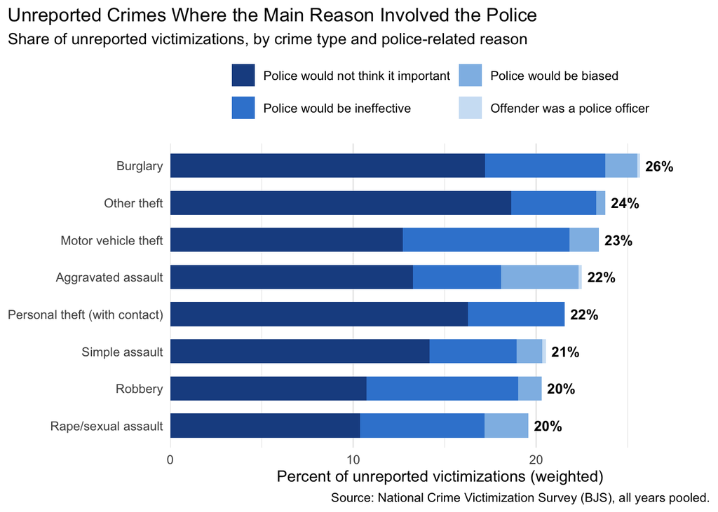

```r
p_police <- ggplot(police_detail,
                   aes(x = pct, y = crime_type, fill = reason_not_reported_most)) +
  geom_col(width = 0.65) +
  geom_text(data = police_by_type,
            aes(x = pct_of_unreported, y = crime_type,
                label = paste0(round(pct_of_unreported), "%")),
            inherit.aes = FALSE, hjust = -0.2, fontface = "bold", size = 3.5) +
  scale_fill_manual(values = c(
    "Police would not think it important" = "#1d4f91",
    "Police would be ineffective"         = "#3a86d4",
    "Police would be biased"              = "#8fbce6",
    "Offender was a police officer"       = "#cfe2f5"),
    breaks = police_reasons) +
  scale_x_continuous(limits = c(0, max(police_by_type$pct_of_unreported) * 1.15),
                     expand = c(0, 0)) +
  labs(
    title = "Unreported Crimes Where the Main Reason Involved the Police",
    subtitle = "Share of unreported victimizations, by crime type and police-related reason",
    x = "Percent of unreported victimizations (weighted)", y = NULL, fill = NULL,
    caption = "Source: National Crime Victimization Survey (BJS), all years pooled."
  ) +
  theme_minimal(base_size = 11) +
  theme(legend.position = "top",
        panel.grid.major.y = element_blank(),
        plot.title.position = "plot") +
  guides(fill = guide_legend(nrow = 2))

p_police
```

# Statistical support for the reporting claims (NCVS 2020–2023)

All estimates below use the NCVS incident weight adjusted for series crimes (`SERIES_IWEIGHT`). Standard errors and 95% confidence intervals use the NCVS variance strata (`V2117`) and PSUs (`V2118`), and the four survey years are pooled. Incidents with “don’t know” or residue on the reported-to-police question are excluded. So are incidents that occurred outside the U.S.

```r
ncvs_valid <- main_df %>%
  filter(reported_police %in% c("Yes", "No"), !is.na(crime_type)) %>%
  mutate(
    unreported = as.numeric(reported_police == "No"),
    # Main reasons with residue / out-of-universe treated as missing
    nr_main       = fct_drop(fct_recode(reason_not_reported_most, NULL = "Residue", NULL = "Oou")),
    nr_main_group = fct_drop(fct_recode(reason_not_reported_group, NULL = "Residue", NULL = "Oou")),
    rep_main_group = fct_drop(fct_recode(reason_reported_group, NULL = "Residue", NULL = "Oou")),
    # The three expectations about police: dismiss the case, fail to help, treat unfairly
    police_dismiss = nr_police_not_important,
    police_no_help = nr_police_ineffective,
    police_unfair  = nr_police_biased,
    police_any3    = pmax(police_dismiss, police_no_help, police_unfair),
    police_main    = case_when(
      is.na(nr_main) ~ NA_real_,
      nr_main %in% c("Police would not think it important", "Police would be ineffective",
                     "Police would be biased") ~ 1,
      TRUE ~ 0)
  )

ncvs_des <- svydesign(ids = ~var_psu, strata = ~design_strata, weights = ~weight_series,
                      nest = TRUE, data = ncvs_valid)
unrep_des <- subset(ncvs_des, unreported == 1)
rep_des   <- subset(ncvs_des, unreported == 0)
n_years   <- n_distinct(ncvs_valid$year)

# Weighted percentage with 95% CI, overall or by a grouping variable
svy_pct <- function(var, design, by = NULL) {
  f <- reformulate(var)
  if (is.null(by)) {
    est <- svymean(f, design, na.rm = TRUE)
    grp <- "All"
  } else {
    est <- svyby(f, reformulate(by), design, svymean, na.rm = TRUE)
    grp <- as.character(est[[by]])
  }
  ci <- confint(est)
  tibble(group   = grp,
         pct     = 100 * as.numeric(coef(est)),
         ci_low  = 100 * ci[, 1],
         ci_high = 100 * ci[, 2])
}

# Distribution of a factor (share in each category) with 95% CI
svy_dist <- function(var, design) {
  est <- svymean(reformulate(var), design, na.rm = TRUE)
  ci  <- confint(est)
  tibble(category = str_remove(names(coef(est)), paste0("^", var)),
         pct      = 100 * as.numeric(coef(est)),
         ci_low   = 100 * ci[, 1],
         ci_high  = 100 * ci[, 2]) %>%
    arrange(desc(pct))
}

fmt_ci <- function(df) {
  df %>% mutate(across(c(pct, ci_low, ci_high), ~ round(.x, 1)),
                `95% CI` = paste0("[", ci_low, ", ", ci_high, "]")) %>%
    select(-ci_low, -ci_high)
}

c(incidents = nrow(ncvs_valid), unreported = sum(ncvs_valid$unreported))
```

```
##  incidents unreported
##      35181      22853
```

## Claim 1: Most crimes go unreported

```r
unrep_overall <- svy_pct("unreported", ncvs_des)
unrep_class   <- svy_pct("unreported", ncvs_des, by = "crime_class")
unrep_year    <- svy_pct("unreported", ncvs_des, by = "year")

# Average annual number of unreported victimizations
unrep_total  <- svytotal(~unreported, ncvs_des)
annual_unrep <- as.numeric(coef(unrep_total)) / n_years

# One-sided test: is the unreported share above 50%?
z_half <- (coef(svymean(~unreported, ncvs_des)) - 0.5) / SE(svymean(~unreported, ncvs_des))
p_half <- pnorm(z_half, lower.tail = FALSE)

claim1_tab <- bind_rows(
  unrep_overall %>% mutate(level = "Overall"),
  unrep_class   %>% mutate(level = "Crime class"),
  unrep_year    %>% mutate(level = "Survey year")
) %>%
  select(level, group, pct, ci_low, ci_high) %>%
  fmt_ci() %>%
  rename(Level = level, Group = group, `% not reported` = pct)

kable(claim1_tab, caption = "Share of victimizations not reported to police (weighted)")
```

Share of victimizations not reported to police (weighted)

| Level | Group | % not reported | 95% CI |
| --- | --- | --- | --- |
| Overall | All | 65.0 | [64.2, 65.9] |
| Crime class | Personal theft | 67.3 | [55.7, 78.8] |
| Crime class | Property | 68.2 | [67.3, 69] |
| Crime class | Violent | 57.3 | [55.4, 59.3] |
| Survey year | 2020 | 65.0 | [63.2, 66.9] |
| Survey year | 2021 | 64.9 | [63.2, 66.6] |
| Survey year | 2022 | 65.1 | [63.3, 66.9] |
| Survey year | 2023 | 65.2 | [63.7, 66.7] |

Across 2020–2023, **65%** of victimizations (95% CI 64.2–65.9%) were not reported to police. That is about **11.5 million** unreported victimizations per year. The share is significantly above 50% (one-sided z = 34.6, p < 0.001). Most violent victimizations (57.3%) and most property victimizations (68.2%) went unreported.

## Claim 2: Reporting varies by crime type

```r
unrep_type <- svy_pct("unreported", ncvs_des, by = "crime_type") %>%
  left_join(count(ncvs_valid, crime_type, name = "n") %>%
              mutate(group = as.character(crime_type)) %>% select(-crime_type),
            by = "group") %>%
  arrange(desc(pct))

# Rao-Scott design-adjusted chi-square test of independence
type_test <- svychisq(~unreported + crime_type, ncvs_des)
type_test
```

```
##
##  Pearson's X^2: Rao & Scott adjustment
##
## data:  svychisq(~unreported + crime_type, ncvs_des)
## F = 102.23, ndf = 6.276, ddf = 4198.656, p-value < 2.2e-16
```

```r
kable(unrep_type %>% fmt_ci() %>%
        rename(`Crime type` = group, `% not reported` = pct, `Unweighted n` = n),
      caption = "Share not reported to police, by crime type")
```

Share not reported to police, by crime type

| Crime type | % not reported | Unweighted n | 95% CI |
| --- | --- | --- | --- |
| Other theft | 73.1 | 22191 | [72.2, 73.9] |
| Rape/sexual assault | 72.0 | 575 | [66.1, 77.9] |
| Personal theft (with contact) | 67.3 | 132 | [55.7, 78.8] |
| Simple assault | 61.4 | 4570 | [58.9, 63.8] |
| Burglary | 57.0 | 3950 | [54.5, 59.5] |
| Robbery | 45.4 | 732 | [38.7, 52.2] |
| Aggravated assault | 45.0 | 1562 | [41, 49] |
| Motor vehicle theft | 22.8 | 1469 | [19.9, 25.8] |

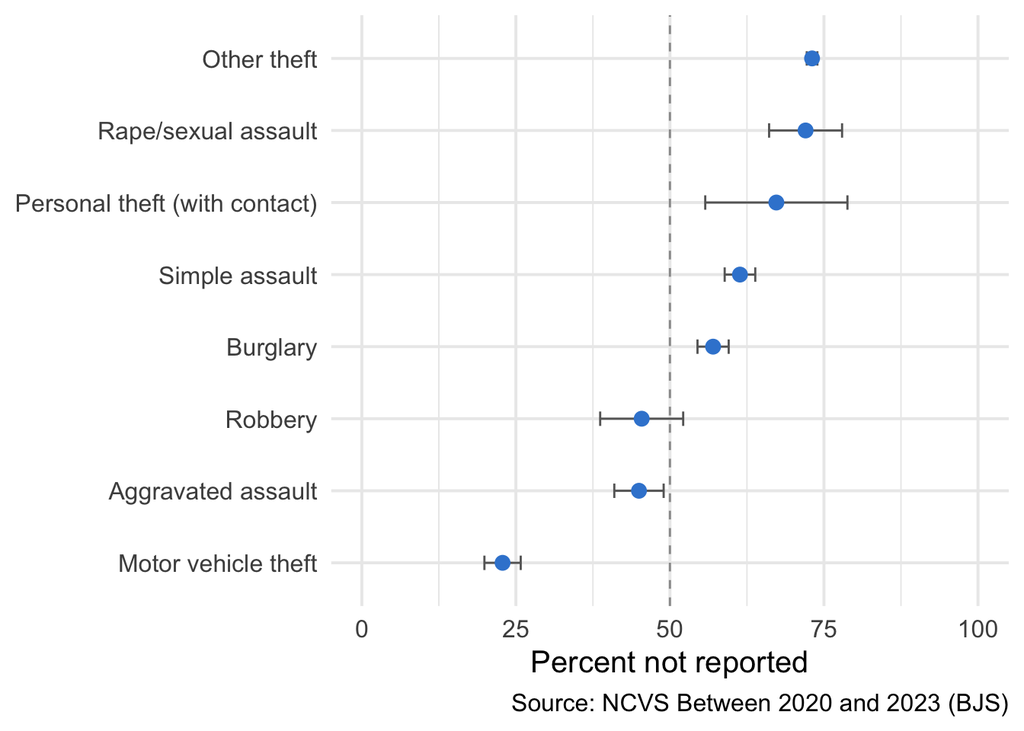

```r
p1 <- ggplot(unrep_type, aes(x = pct, y = fct_reorder(group, pct))) +
  geom_vline(xintercept = 50, linetype = "dashed", color = "grey60") +
  geom_errorbarh(aes(xmin = ci_low, xmax = ci_high), height = 0.2, color = "grey40") +
  geom_point(size = 3, color = "#3a86d4") +
  scale_x_continuous(limits = c(0, 100)) +
  labs(x = "Percent not reported", y = NULL,
       caption = "Source: NCVS Between 2020 and 2023 (BJS)") +
  theme_minimal(base_size = 15) +
  theme(plot.title.position = "plot")

p1
```

```r
ggsave("unreported_by_type.png", p1, width = 8, height = 5.5, dpi = 600)
```

Non-reporting ranges from **23%** (Motor vehicle theft) to **73%** (Other theft). The differences are statistically significant (Rao-Scott F = 102.2, p < 0.001).

## Claim 3: Why victims do and don’t report

```r
# Main reason for NOT reporting (among unreported victimizations)
nr_groups <- svy_dist("nr_main_group", unrep_des)
nr_detail <- svy_dist("nr_main", unrep_des)

# Main reason FOR reporting (among reported victimizations)
rep_groups <- svy_dist("rep_main_group", rep_des)

kable(fmt_ci(nr_groups) %>% rename(`Main reason for not reporting` = category, `%` = pct),
      caption = "Main reason for not reporting (grouped), % of unreported victimizations")
```

Main reason for not reporting (grouped), % of unreported victimizations

| Main reason for not reporting | % | 95% CI |
| --- | --- | --- |
| Not important enough | 28.7 | [27.7, 29.6] |
| Police-related | 24.2 | [23.1, 25.2] |
| Practical barriers | 19.3 | [18.5, 20.2] |
| Handled another way | 10.0 | [9.3, 10.7] |
| Private/personal | 8.1 | [7.5, 8.8] |
| Protecting offender/self | 5.4 | [4.8, 6] |
| Other | 4.3 | [3.7, 4.9] |

```r
kable(fmt_ci(nr_detail) %>% rename(`Main reason for not reporting` = category, `%` = pct),
      caption = "Main reason for not reporting (detailed), % of unreported victimizations")
```

Main reason for not reporting (detailed), % of unreported victimizations

| Main reason for not reporting | % | 95% CI |
| --- | --- | --- |
| Minor or unsuccessful crime | 24.8 | [23.9, 25.7] |
| Police would not think it important | 17.8 | [16.9, 18.8] |
| Reported to another official | 10.0 | [9.3, 10.7] |
| Private or personal matter | 8.1 | [7.5, 8.8] |
| Could not identify offender | 6.8 | [6.3, 7.3] |
| Too inconvenient | 6.4 | [5.9, 7] |
| Police would be ineffective | 5.2 | [4.7, 5.7] |
| Other reason | 3.6 | [3, 4.1] |
| Found out too late | 3.5 | [3.1, 3.9] |
| Did not want to get offender in trouble | 2.9 | [2.5, 3.4] |
| Could not recover property | 2.6 | [2.3, 2.9] |
| Fear of reprisal | 2.1 | [1.7, 2.5] |
| Not clear it was a crime | 2.0 | [1.7, 2.4] |
| Police would be biased | 1.0 | [0.8, 1.3] |
| No insurance, loss below deductible | 0.9 | [0.8, 1.1] |
| Child offender, kid stuff | 0.9 | [0.7, 1.1] |
| Respondent not present, don’t know | 0.7 | [0.5, 0.8] |
| Advised not to report | 0.3 | [0.2, 0.4] |
| Offender was a police officer | 0.1 | [0, 0.1] |
| No one reason more important | 0.0 | [0, 0.1] |

```r
kable(fmt_ci(rep_groups) %>% rename(`Main reason for reporting` = category, `%` = pct),
      caption = "Main reason for reporting (grouped), % of reported victimizations")
```

Main reason for reporting (grouped), % of reported victimizations

| Main reason for reporting | % | 95% CI |
| --- | --- | --- |
| Civic duty | 36.0 | [34.5, 37.6] |
| Stop or prevent crime | 32.7 | [31, 34.3] |
| Get help or recover losses | 21.6 | [20.4, 22.7] |
| Other | 6.1 | [5.3, 7] |
| Hold offender accountable | 3.6 | [3, 4.2] |

## Claim 4: When police are the reason

Victims could give more than one reason for not reporting (Q.117), then name the most important one (Q.118). The NCVS has three police-related items that match the expectations of interest:

- **Dismiss the case** (`V4411`): police wouldn’t think it was important enough, or wouldn’t want to be bothered or get involved.
- **Fail to help** (`V4412`): police would be inefficient or ineffective (arrive late or not at all, wouldn’t do a good job).
- **Treat them unfairly** (`V4413`): police would be biased, would harass or insult the respondent, or would cause trouble.

```r
police_items <- c(
  "Dismiss the case (not important / not bothered)" = "police_dismiss",
  "Fail to help (ineffective)"                      = "police_no_help",
  "Treat unfairly (biased / harass)"                = "police_unfair",
  "Any of the three"                                = "police_any3",
  "Main reason was one of the three"                = "police_main"
)

police_tab <- imap_dfr(police_items, ~ svy_pct(.x, unrep_des) %>% mutate(item = .y)) %>%
  select(item, pct, ci_low, ci_high)

# Share of ALL victimizations that went unreported at least partly for these reasons
ncvs_des <- update(ncvs_des,
                   police_any3_all = if_else(unreported == 1, police_any3, 0),
                   police_main_all = if_else(unreported == 1, police_main, 0))
police_all <- svy_pct("police_any3_all", ncvs_des)
police_main_all <- svy_pct("police_main_all", ncvs_des)
annual_police <- as.numeric(coef(svytotal(~police_any3_all, ncvs_des, na.rm = TRUE))) / n_years

kable(police_tab %>% fmt_ci() %>% rename(`Reason (any mention)` = item, `% of unreported` = pct),
      caption = "Unreported victimizations where victims expected police to dismiss, fail to help, or treat them unfairly")
```

Unreported victimizations where victims expected police to dismiss, fail to help, or treat them unfairly

| Reason (any mention) | % of unreported | 95% CI |
| --- | --- | --- |
| Dismiss the case (not important / not bothered) | 23.2 | [22.2, 24.2] |
| Fail to help (ineffective) | 7.4 | [6.8, 8] |
| Treat unfairly (biased / harass) | 1.5 | [1.2, 1.7] |
| Any of the three | 29.0 | [27.9, 30.1] |
| Main reason was one of the three | 24.1 | [23, 25.2] |

```r
# By crime type, class, and year
police_type  <- svy_pct("police_any3", unrep_des, by = "crime_type") %>% arrange(desc(pct))
police_class <- svy_pct("police_any3", unrep_des, by = "crime_class")
police_year  <- svy_pct("police_any3", unrep_des, by = "year")
police_type_test <- svychisq(~police_any3 + crime_type, unrep_des)

kable(bind_rows(police_class %>% mutate(Level = "Crime class"),
                police_type  %>% mutate(Level = "Crime type"),
                police_year  %>% mutate(Level = "Survey year")) %>%
        relocate(Level) %>% fmt_ci() %>%
        rename(Group = group, `% of unreported citing any of the three` = pct),
      caption = "Police-related reasons (any mention) by crime class, type, and year")
```

Police-related reasons (any mention) by crime class, type, and year

| Level | Group | % of unreported citing any of the three | 95% CI |
| --- | --- | --- | --- |
| Crime class | Personal theft | 23.8 | [7.8, 39.9] |
| Crime class | Property | 30.4 | [29.2, 31.5] |
| Crime class | Violent | 25.1 | [22.5, 27.6] |
| Crime type | Burglary | 31.1 | [28.1, 34.1] |
| Crime type | Robbery | 31.0 | [21.3, 40.6] |
| Crime type | Motor vehicle theft | 30.3 | [23.5, 37.1] |
| Crime type | Other theft | 30.3 | [29.1, 31.5] |
| Crime type | Aggravated assault | 27.4 | [21.8, 33.1] |
| Crime type | Simple assault | 24.0 | [21, 27] |
| Crime type | Personal theft (with contact) | 23.8 | [7.8, 39.9] |
| Crime type | Rape/sexual assault | 23.6 | [17.4, 29.8] |
| Survey year | 2020 | 25.5 | [23.3, 27.7] |
| Survey year | 2021 | 27.9 | [25.7, 30.1] |
| Survey year | 2022 | 30.4 | [28.4, 32.4] |
| Survey year | 2023 | 31.5 | [29.2, 33.8] |

```r
police_type_test
```

```
##
##  Pearson's X^2: Rao & Scott adjustment
##
## data:  svychisq(~police_any3 + crime_type, unrep_des)
## F = 3.0269, ndf = 6.1294, ddf = 3953.4863, p-value = 0.00554
```

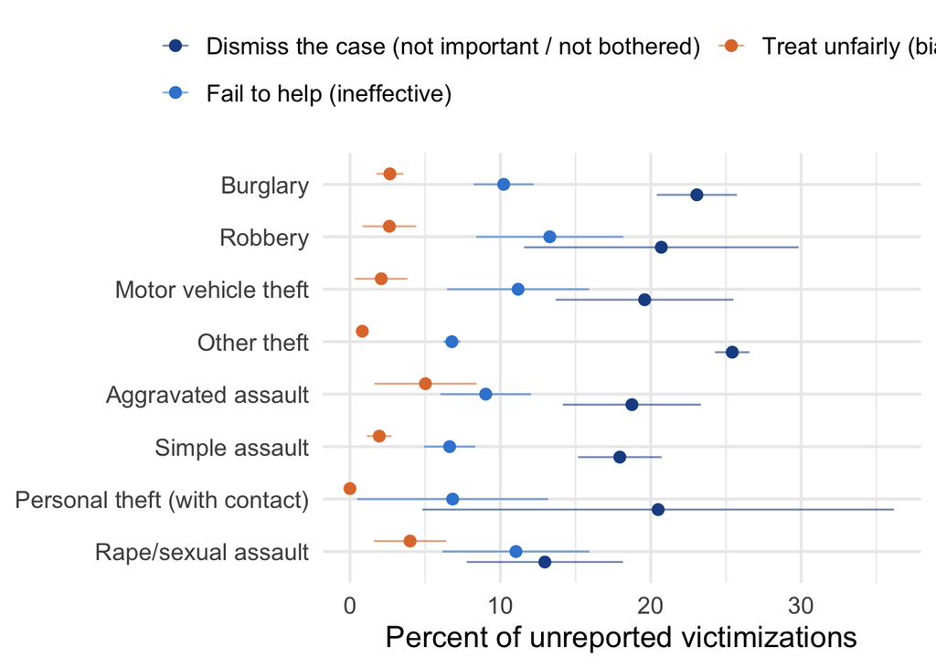

```r
police_detail_any <- imap_dfr(police_items[1:3],
                              ~ svy_pct(.x, unrep_des, by = "crime_type") %>% mutate(item = .y)) %>%
  mutate(item = factor(item, levels = names(police_items)[1:3]),
         group = factor(group, levels = rev(police_type$group)))

p_police_reason <- ggplot(police_detail_any, aes(x = pct, y = group, color = item)) +
  geom_errorbarh(aes(xmin = ci_low, xmax = ci_high), height = 0,
                 position = position_dodge(width = 0.6), alpha = 0.6) +
  geom_point(size = 2.6, position = position_dodge(width = 0.6)) +
  scale_color_manual(values = c("#1d4f91", "#3a86d4", "#e07a3a")) +
  labs(x = "Percent of unreported victimizations", y = NULL, color = NULL) +
  theme_minimal(base_size = 16) +
  theme(legend.position = "top", plot.title.position = "plot") +
  guides(color = guide_legend(nrow = 2))

p_police_reason
```

```r
ggsave("police_reasons_by_type.png", p_police_reason, width = 10, height = 6.5, dpi = 600)
```

Among unreported victimizations, **29%** (95% CI 27.9–30.1%) went unreported at least partly because the victim expected police to dismiss the case, fail to help, or treat them unfairly. By item:

- **Dismiss the case:** 23.2%
- **Fail to help:** 7.4%
- **Treat unfairly:** 1.5%

One of these was the *most important* reason for 24.1% of unreported victimizations. Across all victimizations, reported or not, 18.9% went unreported at least partly for these reasons. That is roughly **3.3 million victimizations per year**.

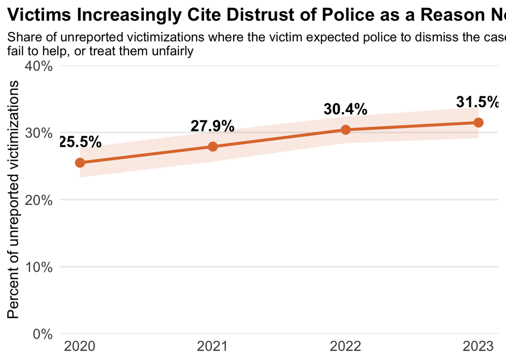

```r
trend_df <- police_year %>%
  mutate(year = as.numeric(as.character(group)))

p_police_trend <- ggplot(trend_df, aes(x = year, y = pct)) +
  geom_ribbon(aes(ymin = ci_low, ymax = ci_high), fill = "#e07a3a", alpha = 0.15) +
  geom_line(color = "#e07a3a", linewidth = 1.4) +
  geom_point(color = "#e07a3a", size = 4) +
  geom_text(aes(label = paste0(round(pct, 1), "%")),
            vjust = -1.4, fontface = "bold", size = 5.5) +
  scale_x_continuous(breaks = trend_df$year) +
  scale_y_continuous(limits = c(0, 40), breaks = seq(0, 40, 10),
                     labels = function(x) paste0(x, "%"), expand = c(0, 0)) +
  labs(
    title = "Victims Increasingly Cite Distrust of Police as a Reason Not to Report",
    subtitle = "Share of unreported victimizations where the victim expected police to dismiss the case,\nfail to help, or treat them unfairly",
    x = NULL, y = "Percent of unreported victimizations"
  ) +
  theme_minimal(base_size = 15) +
  theme(
    panel.grid.minor = element_blank(),
    panel.grid.major.x = element_blank(),
    plot.title = element_text(face = "bold", size = 18),
    plot.subtitle = element_text(size = 13),
    plot.caption = element_text(size = 10, hjust = 0),
    axis.text = element_text(size = 14),
    plot.title.position = "plot",
    plot.caption.position = "plot"
  )

p_police_trend
```

```r
ggsave("police_reasons_trend.png", p_police_trend, width = 10, height = 6.5, dpi = 600)
```

# Past police violations and willingness to contact police (PPCS 2020 and 2022)

```r
`38872.0001.Data` <- read.delim("ICPSR_38872/DS0001/38872-0001-Data.tsv")

`38320.0001.Data` <- read.delim("ICPSR_38320/DS0001/38320-0001-Data.tsv")
```

```r
ppcs_vars <- c("PPCSWGT", "PSSTRATA", "SECUCODE", "AGE", "SEX", "HISP", "INCOME",
               "V351A", "V351B", "V352A", "V352B", "V352C", "V352D", "V352E",
               "V342", "V23A", "V23B", "V23C", "V24D")

ppcs22 <- `38872.0001.Data` %>% select(all_of(ppcs_vars)) %>% mutate(year = 2022)

ppcs20 <- `38320.0001.Data` %>% select(all_of(ppcs_vars)) %>% mutate(year = 2020)

ppcs <- bind_rows(ppcs20, ppcs22)
```

**Outcome.** `V342` asks: *“Would you be more likely, less likely, or just as likely to contact the police in the future?”* It is asked of respondents whose most recent police contact in the past 12 months they initiated themselves: reporting a crime, reporting a non-crime emergency, asking for non-emergency help, or seeking help for something else. The main outcome is **less likely to contact police in the future** (1) versus just as or more likely (0). An ordered logit on all three categories serves as a robustness check. “Don’t know” and refused are excluded.

**Violations and threats.** All yes/no items are coded 1 = Yes, 2 = No in the PPCS.

- *During the most recent contact* (`V351A`/`V351B`, asked only for face-to-face contacts): police used force; police threatened force.
- *During earlier contacts in the past 12 months* (`V352A`–`E`, asked only of respondents with more than one contact): police used force; threatened force; used a slur or degrading name; made a sexual comment; touched the respondent sexually.

Respondents outside an item’s universe are coded 0 for that item. That means a contact that wasn’t face-to-face, or no earlier contact, so no such event was possible. “Don’t know”, residue, and refused are coded missing. Restricting each block to its own universe is shown as a robustness check.

**Controls.** Sex, age group, race/ethnicity, and household income, plus survey year. Income is harmonized to under $75,000 versus $75,000 or more, because the 2022 file collapses the lower categories.

**Design.** Models are survey-weighted logits (`PPCSWGT`), with variance strata `PSSTRATA` (nested within year) and PSU `SECUCODE`.

```r
# 1 = Yes; 2 = No and 9 = out of universe (no such event possible) -> 0; DK/residue/refused -> NA
yes_no <- function(x) case_when(x == 1 ~ 1, x %in% c(2, 9) ~ 0, TRUE ~ NA_real_)

ppcs_model <- ppcs %>%
  filter(V342 %in% 1:3) %>%                       # asked, and gave a substantive answer
  mutate(
    contact_future = factor(V342, levels = c(2, 3, 1),
                            labels = c("Less likely", "Just as likely", "More likely"),
                            ordered = TRUE),
    less_likely_contact_01 = as.numeric(V342 == 2),
    face_to_face   = V351A != 9,                  # in universe for current-contact items
    multi_contact  = V352A != 9,                  # in universe for earlier-contact items
    across(c(V351A, V351B, V352A, V352B, V352C, V352D, V352E), yes_no),
    force_now      = V351A,
    threat_now     = V351B,
    force_prior    = V352A,
    threat_prior   = V352B,
    slur_prior     = V352C,
    sexual_prior   = pmax(V352D, V352E),          # sexual comment or sexual touching
    force_any      = pmax(force_now, force_prior),
    threat_any     = pmax(threat_now, threat_prior),
    prior_violation = pmax(force_prior, threat_prior, slur_prior, sexual_prior),
    any_violation  = pmax(force_any, threat_any, slur_prior, sexual_prior),
    # Mutually exclusive "most serious" type of violation
    violation_type = case_when(
      is.na(any_violation)                 ~ NA_character_,
      force_any == 1                       ~ "Force used",
      threat_any == 1                      ~ "Threat of force only",
      slur_prior == 1 | sexual_prior == 1  ~ "Slur or sexual misconduct only",
      TRUE                                 ~ "None"),
    violation_type = factor(violation_type, levels = c("None", "Threat of force only", "Force used",
                                                       "Slur or sexual misconduct only")),
    sex      = factor(SEX, 1:2, c("Male", "Female")),
    age      = factor(AGE, 1:5, c("16-17", "18-24", "25-44", "45-64", "65+")),
    race_eth = factor(HISP, 1:5, c("White", "Black", "Hispanic", "Asian", "Other")),
    income   = factor(if_else(INCOME == 4, "$75,000+", "Under $75,000"),
                      levels = c("Under $75,000", "$75,000+")),
    year     = factor(year),
    strata   = interaction(year, PSSTRATA, drop = TRUE)
  ) %>%
  filter(!is.na(any_violation))

# Cell sizes: violations are rare, so check how many respondents fall in each group
ppcs_model %>%
  count(violation_type, contact_future) %>%
  pivot_wider(names_from = contact_future, values_from = n, values_fill = 0) %>%
  kable(caption = "Unweighted counts: violation type by future-contact intention")
```

Unweighted counts: violation type by future-contact intention

| violation_type | Less likely | Just as likely | More likely |
| --- | --- | --- | --- |
| None | 988 | 13389 | 4413 |
| Threat of force only | 10 | 17 | 6 |
| Force used | 13 | 78 | 35 |
| Slur or sexual misconduct only | 3 | 11 | 2 |

```r
ppcs_model %>%
  summarise(across(c(force_now, threat_now, force_prior, threat_prior, slur_prior, sexual_prior),
                   ~ sum(.x, na.rm = TRUE))) %>%
  pivot_longer(everything(), names_to = "item", values_to = "n_yes") %>%
  kable(caption = "Unweighted number of respondents reporting each violation")
```

Unweighted number of respondents reporting each violation

| item | n_yes |
| --- | --- |
| force_now | 95 |
| threat_now | 82 |
| force_prior | 39 |
| threat_prior | 42 |
| slur_prior | 25 |
| sexual_prior | 17 |

```r
des <- svydesign(ids = ~SECUCODE, strata = ~strata, weights = ~PPCSWGT,
                 nest = TRUE, data = ppcs_model)

controls <- "+ sex + age + race_eth + income + year"
fit <- function(rhs, design = des) {
  svyglm(as.formula(paste("less_likely_contact_01 ~", rhs, controls)),
         design = design, family = quasibinomial())
}

m0 <- svyglm(less_likely_contact_01 ~ any_violation, design = des,
             family = quasibinomial())                                    # unadjusted
m1 <- fit("any_violation")                                                # any violation
m2 <- fit("violation_type")                                               # most serious type
m3 <- fit("force_any + threat_any + slur_prior + sexual_prior")           # each type, jointly
m4 <- fit("force_now + threat_now + prior_violation")                     # timing

coef_labels <- c(
  "any_violation" = "Any violation or threat",
  "violation_typeThreat of force only" = "Type: threat of force only",
  "violation_typeForce used" = "Type: force used",
  "violation_typeSlur or sexual misconduct only" = "Type: slur or sexual misconduct only",
  "force_any" = "Force used (any contact)",
  "threat_any" = "Threat of force (any contact)",
  "slur_prior" = "Slur / degrading name (earlier contact)",
  "sexual_prior" = "Sexual comment or touching (earlier contact)",
  "force_now" = "Force used (most recent contact)",
  "threat_now" = "Threat of force (most recent contact)",
  "force_prior" = "Force used (earlier contact)",
  "threat_prior" = "Threat of force (earlier contact)",
  "prior_violation" = "Any violation (earlier contacts)",
  "sexFemale" = "Female",
  "age18-24" = "Age 18-24", "age25-44" = "Age 25-44",
  "age45-64" = "Age 45-64", "age65+" = "Age 65+",
  "race_ethBlack" = "Black", "race_ethHispanic" = "Hispanic",
  "race_ethAsian" = "Asian", "race_ethOther" = "Other race",
  "income$75,000+" = "Income $75,000+",
  "year2022" = "Year 2022",
  "(Intercept)" = "Constant")

modelsummary(
  list("Unadjusted" = m0, "Any violation" = m1, "Most serious type" = m2,
       "Each type" = m3, "Timing" = m4),
  exponentiate = TRUE, stars = c("+" = .1, "*" = .05, "**" = .01, "***" = .001),
  coef_map = coef_labels, gof_map = "nobs",
  title = "Survey-weighted logistic regression: less likely to contact police in the future (odds ratios, SEs in parentheses)",
  notes = "Reference categories: male, age 16-17, White, income under $75,000, 2020. Design-based SEs (PSSTRATA, SECUCODE)."
)
```

|  | Unadjusted | Any violation | Most serious type | Each type | Timing |
| --- | --- | --- | --- | --- | --- |
| Any violation or threat | 3.746*** | 3.684*** |  |  |  |
|  | (0.879) | (0.843) |  |  |  |
| Type: threat of force only |  |  | 5.457*** |  |  |
|  |  |  | (2.286) |  |  |
| Type: force used |  |  | 2.892** |  |  |
|  |  |  | (0.926) |  |  |
| Type: slur or sexual misconduct only |  |  | 5.700* |  |  |
|  |  |  | (3.915) |  |  |
| Force used (any contact) |  |  |  | 1.084 |  |
|  |  |  |  | (0.551) |  |
| Threat of force (any contact) |  |  |  | 3.438** |  |
|  |  |  |  | (1.521) |  |
| Slur / degrading name (earlier contact) |  |  |  | 4.135+ |  |
|  |  |  |  | (3.161) |  |
| Sexual comment or touching (earlier contact) |  |  |  | 0.273 |  |
|  |  |  |  | (0.308) |  |
| Force used (most recent contact) |  |  |  |  | 0.612 |
|  |  |  |  |  | (0.473) |
| Threat of force (most recent contact) |  |  |  |  | 4.267* |
|  |  |  |  |  | (2.767) |
| Any violation (earlier contacts) |  |  |  |  | 3.008** |
|  |  |  |  |  | (1.108) |
| Female |  | 1.080 | 1.082 | 1.080 | 1.078 |
|  |  | (0.084) | (0.084) | (0.084) | (0.083) |
| Age 18-24 |  | 1.270 | 1.257 | 1.275 | 1.257 |
|  |  | (0.578) | (0.575) | (0.579) | (0.574) |
| Age 25-44 |  | 1.091 | 1.079 | 1.093 | 1.081 |
|  |  | (0.465) | (0.461) | (0.465) | (0.462) |
| Age 45-64 |  | 0.936 | 0.925 | 0.942 | 0.927 |
|  |  | (0.393) | (0.390) | (0.395) | (0.391) |
| Age 65+ |  | 0.650 | 0.645 | 0.654 | 0.647 |
|  |  | (0.280) | (0.279) | (0.282) | (0.281) |
| Black |  | 1.648*** | 1.644*** | 1.650*** | 1.646*** |
|  |  | (0.195) | (0.196) | (0.195) | (0.196) |
| Hispanic |  | 1.328* | 1.326* | 1.330* | 1.329* |
|  |  | (0.168) | (0.168) | (0.168) | (0.168) |
| Asian |  | 1.444+ | 1.439+ | 1.443+ | 1.442+ |
|  |  | (0.290) | (0.288) | (0.291) | (0.290) |
| Other race |  | 1.769** | 1.759** | 1.780** | 1.774** |
|  |  | (0.336) | (0.333) | (0.337) | (0.337) |
| Income $75,000+ |  | 0.774** | 0.776** | 0.775** | 0.773** |
|  |  | (0.063) | (0.063) | (0.063) | (0.063) |
| Year 2022 |  | 1.166+ | 1.165+ | 1.165+ | 1.157+ |
|  |  | (0.096) | (0.096) | (0.096) | (0.095) |
| Constant | 0.059*** | 0.052*** | 0.053*** | 0.052*** | 0.053*** |
|  | (0.002) | (0.022) | (0.022) | (0.022) | (0.022) |
| Num.Obs. | 18965 | 18965 | 18965 | 18965 | 18965 |

+ p < 0.1, * p < 0.05, ** p < 0.01, *** p < 0.001  
Reference categories: male, age 16-17, White, income under $75,000, 2020. Design-based SEs (PSSTRATA, SECUCODE).

### Average marginal effects (percentage points)

Odds ratios are hard to read for a rare outcome, so the table below converts them to average changes in the probability of saying “less likely to contact police.”

```r
ame <- bind_rows(
  avg_slopes(m1, variables = "any_violation", wts = "(weights)") %>% as.data.frame(),
  avg_slopes(m2, variables = "violation_type", wts = "(weights)") %>% as.data.frame(),
  avg_slopes(m3, variables = c("force_any", "threat_any", "slur_prior", "sexual_prior"),
             wts = "(weights)") %>% as.data.frame(),
  avg_slopes(m4, variables = c("force_now", "threat_now", "prior_violation"),
             wts = "(weights)") %>% as.data.frame(),
  .id = "model"
) %>%
  mutate(model = c("Any violation", "Most serious type", "Each type", "Timing")[as.integer(model)],
         term = if_else(term == "violation_type", paste("Type:", contrast), term),
         across(c(estimate, conf.low, conf.high), ~ round(100 * .x, 1)),
         p.value = format.pval(p.value, digits = 2, eps = 0.001)) %>%
  select(Model = model, Term = term, `AME (pp)` = estimate,
         `CI low` = conf.low, `CI high` = conf.high, p = p.value)

kable(ame, caption = "Average marginal effects on P(less likely to contact police), percentage points")
```

Average marginal effects on P(less likely to contact police), percentage points

| Model | Term | AME (pp) | CI low | CI high | p |
| --- | --- | --- | --- | --- | --- |
| Any violation | any_violation | 12.1 | 5.6 | 18.5 | <0.001 |
| Most serious type | Type: Force used - None | 8.9 | 1.2 | 16.5 | 0.024 |
| Most serious type | Type: Slur or sexual misconduct only - None | 19.1 | -5.5 | 43.8 | 0.128 |
| Most serious type | Type: Threat of force only - None | 18.4 | 3.7 | 33.0 | 0.014 |
| Each type | force_any | 0.4 | -5.2 | 6.1 | 0.877 |
| Each type | sexual_prior | -4.1 | -7.6 | -0.5 | 0.025 |
| Each type | slur_prior | 13.9 | -9.2 | 37.0 | 0.239 |
| Each type | threat_any | 11.1 | -0.7 | 23.0 | 0.066 |
| Timing | force_now | -2.1 | -7.3 | 3.1 | 0.426 |
| Timing | prior_violation | 9.4 | 0.3 | 18.5 | 0.043 |
| Timing | threat_now | 14.3 | -5.5 | 34.2 | 0.157 |

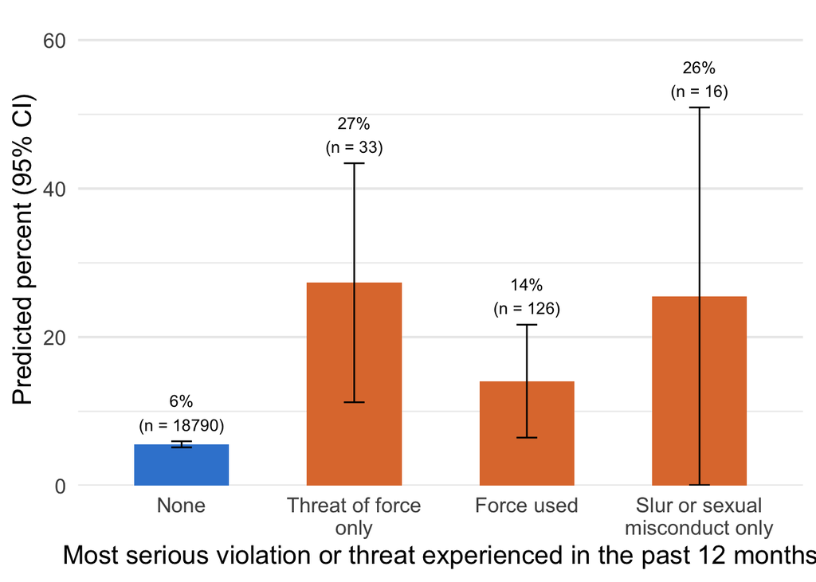

```r
# ---- Predicted probabilities by most serious violation type ----
pred_df <- avg_predictions(m2, by = "violation_type", wts = "(weights)") %>%
  as.data.frame() %>%
  left_join(count(ppcs_model, violation_type, name = "n"), by = "violation_type")

p_pred <- ggplot(pred_df, aes(x = violation_type, y = estimate * 100,
                              fill = violation_type == "None")) +
  geom_col(width = 0.55) +
  geom_errorbar(aes(ymin = pmax(conf.low, 0) * 100, ymax = conf.high * 100), width = 0.12) +
  geom_text(aes(label = paste0(round(estimate * 100), "%\n(n = ", n, ")"),
                y = conf.high * 100), vjust = -0.3, size = 3.6) +
  scale_fill_manual(values = c("TRUE" = "#3a86d4", "FALSE" = "#e07a3a"), guide = "none") +
  scale_x_discrete(labels = function(x) str_wrap(x, 16)) +
  scale_y_continuous(limits = c(0, max(pred_df$conf.high * 100) * 1.25), expand = c(0, 0)) +
  labs(
    x = "Most serious violation or threat experienced in the past 12 months",
    y = "Predicted percent (95% CI)",
  ) +
  theme_minimal(base_size = 16) +
  theme(panel.grid.major.x = element_blank(), plot.title.position = "plot")

p_pred
```

```r
ggsave("ppcs_predicted.png", p_pred, width = 8, height = 5.5, dpi = 600)
```

### Robustness checks

```r
# (a) Ordered logit on all three response categories (higher = more likely to contact)
o1 <- svyolr(contact_future ~ any_violation + sex + age + race_eth + income + year, design = des)
o2 <- svyolr(contact_future ~ violation_type + sex + age + race_eth + income + year, design = des)

# (b) Restrict each block of items to the respondents who were actually asked it
r_face  <- fit("force_now + threat_now", design = subset(des, face_to_face))
r_multi <- fit("force_prior + threat_prior + slur_prior + sexual_prior", design = subset(des, multi_contact))

modelsummary(
  list("Ordered logit: any" = o1, "Ordered logit: type" = o2,
       "Face-to-face only" = r_face, "Multiple contacts only" = r_multi),
  exponentiate = TRUE, stars = c("+" = .1, "*" = .05, "**" = .01, "***" = .001),
  coef_map = coef_labels[!names(coef_labels) %in% "(Intercept)"], gof_map = "nobs",
  title = "Robustness checks (odds ratios)",
  notes = "Ordered logits: OR < 1 means lower odds of a more-likely response. Columns 3-4 model 'less likely' (binary) within each item's universe."
)
```

|  | Ordered logit: any | Ordered logit: type | Face-to-face only | Multiple contacts only |
| --- | --- | --- | --- | --- |
| Any violation or threat | 0.569+ |  |  |  |
|  | (0.174) |  |  |  |
| Type: threat of force only |  | 0.226** |  |  |
|  |  | (0.112) |  |  |
| Type: force used |  | 0.848 |  |  |
|  |  | (0.293) |  |  |
| Type: slur or sexual misconduct only |  | 0.246 |  |  |
|  |  | (0.234) |  |  |
| Slur / degrading name (earlier contact) |  |  |  | 4.871* |
|  |  |  |  | (3.717) |
| Sexual comment or touching (earlier contact) |  |  |  | 0.245 |
|  |  |  |  | (0.280) |
| Force used (most recent contact) |  |  | 0.718 |  |
|  |  |  | (0.523) |  |
| Threat of force (most recent contact) |  |  | 5.476** |  |
|  |  |  | (3.206) |  |
| Force used (earlier contact) |  |  |  | 2.170 |
|  |  |  |  | (1.229) |
| Threat of force (earlier contact) |  |  |  | 1.531 |
|  |  |  |  | (0.847) |
| Female | 1.020 | 1.019 | 1.120 | 1.062 |
|  | (0.038) | (0.038) | (0.115) | (0.121) |
| Age 18-24 | 0.560* | 0.560* | 1.688 | 1.075 |
|  | (0.156) | (0.157) | (0.891) | (0.602) |
| Age 25-44 | 0.606+ | 0.607+ | 1.311 | 0.909 |
|  | (0.163) | (0.164) | (0.658) | (0.480) |
| Age 45-64 | 0.741 | 0.742 | 1.183 | 0.737 |
|  | (0.199) | (0.200) | (0.577) | (0.384) |
| Age 65+ | 0.944 | 0.944 | 0.846 | 0.624 |
|  | (0.255) | (0.256) | (0.423) | (0.336) |
| Black | 1.661*** | 1.665*** | 1.872*** | 1.908*** |
|  | (0.140) | (0.140) | (0.293) | (0.321) |
| Hispanic | 1.615*** | 1.616*** | 1.503* | 1.155 |
|  | (0.111) | (0.111) | (0.242) | (0.208) |
| Asian | 1.215+ | 1.218+ | 1.320 | 1.621+ |
|  | (0.136) | (0.137) | (0.433) | (0.464) |
| Other race | 0.863 | 0.868 | 2.110*** | 1.617+ |
|  | (0.114) | (0.114) | (0.474) | (0.452) |
| Income $75,000+ | 0.876*** | 0.874*** | 0.738** | 0.845 |
|  | (0.035) | (0.034) | (0.086) | (0.105) |
| Year 2022 | 0.974 | 0.974 | 1.118 | 1.260+ |
|  | (0.044) | (0.044) | (0.127) | (0.155) |
| Num.Obs. | 18965 | 18965 | 10758 | 6785 |

+ p < 0.1, * p < 0.05, ** p < 0.01, *** p < 0.001  
Ordered logits: OR < 1 means lower odds of a more-likely response. Columns 3-4 model 'less likely' (binary) within each item's universe.

**Interpretation notes.**

- Violations are rare: roughly 1% of the analytic sample reports any violation or threat. Estimates for slurs and sexual misconduct rest on a few dozen cases or fewer, so they are imprecise and should be read as suggestive.
- Force and threats of force overlap heavily. Most people who had force used against them were also threatened. The “most serious type” model separates them into mutually exclusive groups.
- The data are cross-sectional and the outcome is self-reported, so these associations are not causal. Respondents who already distrust police may both report more violations and say they are less likely to call.